# What drives housing prices in the Lille metropolitan area?

Public property sales (DVF), 2021-2025

Maureen Wiart

October 2026

## The question

Buyers, lenders and estate agents all ask the same thing: **is this price in line with the market?** This report uses every recorded sale of a flat or a house in the 95 communes of the Métropole Européenne de Lille between 2021 and 2025 to answer three questions:

1. How have prices moved since 2021, once differences in the homes sold are taken into account?
2. How much does location matter?
3. How well can a home’s price be estimated from public data, and which sales stand out?

**Data.** *Demandes de valeurs foncières géolocalisées* (DVF), published by Etalab from the tax administration’s records, open licence. One row per item of a sale; a sale with a flat, a cellar and a parking space appears three times with the same total price. To get a reliable price per m², the analysis keeps sales of exactly one dwelling (with or without outbuildings) and removes implausible values.

| Step | Rows |
| --- | --- |
| Rows in the Nord files, 2021-2025 | 553,756 |
| Sale rows in the 95 MEL communes | 211,037 |
| Sales of exactly one dwelling | 76,689 |
| After quality filters (surface, price, price per m²) | 76,047 |

## 1. Prices since 2021

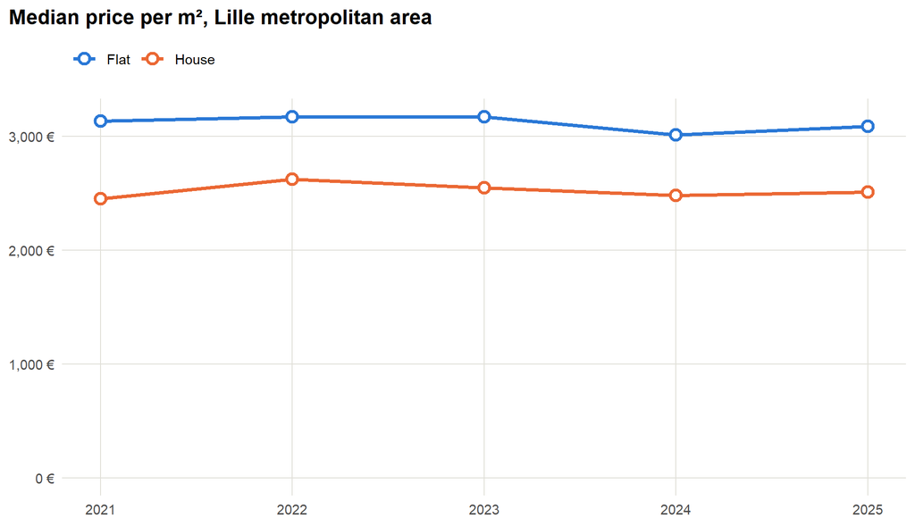

Median prices per m² barely move: flats went from 3,131 € in 2021 to 3,084 € in 2025. But medians can mislead: when interest rates rose in 2023, fewer first-time buyers bought small flats, so the *mix* of homes sold changed.

A **quality-adjusted index** separates the two effects. A regression explains the log of the price per m² by the commune, the type of home, its surface and number of rooms, and one coefficient per year: that coefficient is the price change for a comparable home.

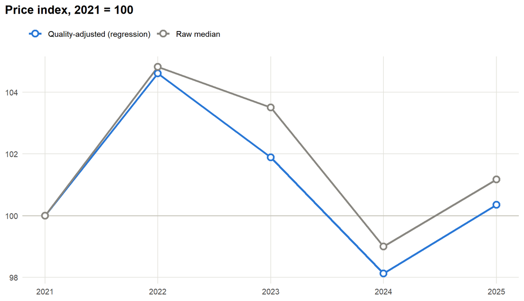

| Year | Quality-adjusted index | Raw median index |
| --- | --- | --- |
| 2021 | 100.0 | 100.0 |
| 2022 | 104.6 | 104.8 |
| 2023 | 101.9 | 103.5 |
| 2024 | 98.1 | 99.0 |
| 2025 | 100.4 | 101.2 |

Comparable homes gained about 5% in 2022, then lost about 6% by 2024 as rates rose, before recovering in 2025 to roughly their 2021 level. The raw median overstates 2023: the homes sold that year were, on average, more expensive kinds of homes.

## 2. Location

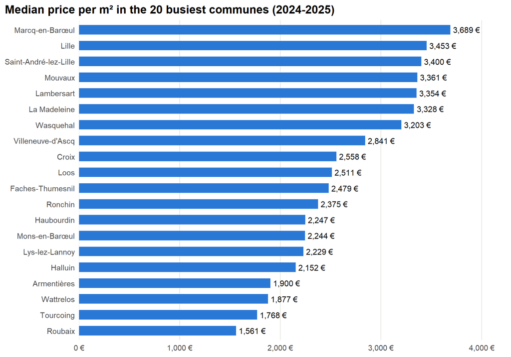

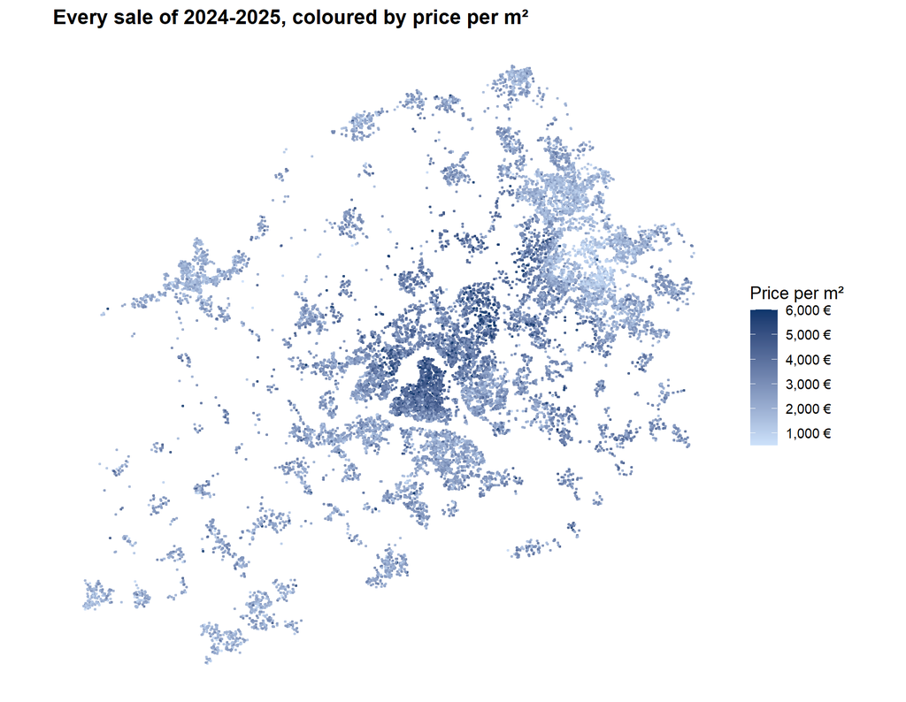

A square metre costs more than twice as much in Marcq-en-Barœul or Lille as in Roubaix or Tourcoing, a few kilometres away. The map shows the gradient: the centre of Lille and the north-western suburbs on one side, the north-eastern former textile towns on the other.

## 3. Estimating a price

The valuation model explains the log of the price by the log of the surface (with a different slope for houses), the number of rooms, the commune and the quarter of the sale. It was fitted on 80% of the sales and tested on the other 20%.

| Measure | Value |
| --- | --- |
| Share of price variation explained (R², training) | 0.632 |
| Sales in the test set | 15,292 |
| Median error on test sales | 20.8% |
| Test sales within ±20% of the estimate | 48.5% |
| Sold more than 50% above the estimate | 8.7% |
| Sold more than 50% below the estimate | 3.2% |

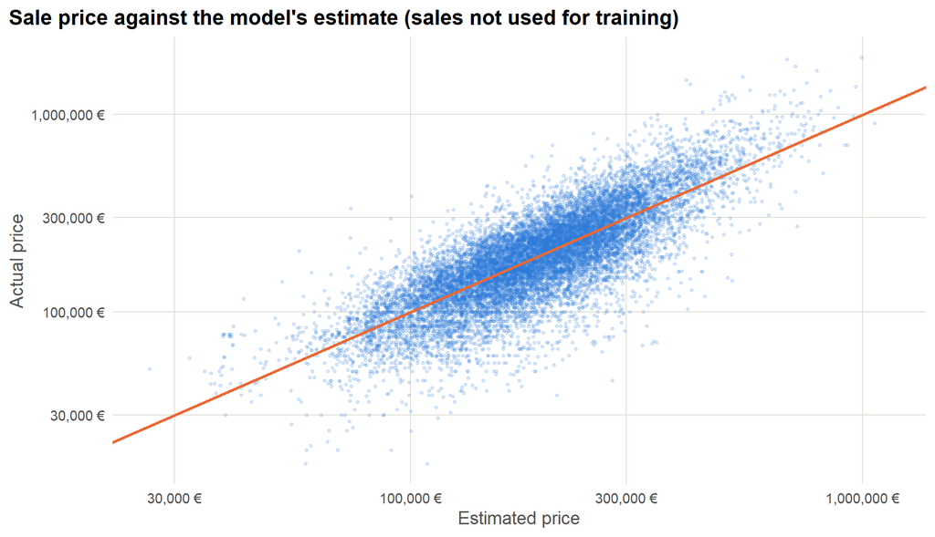

A typical error of about ±21% is honest for public data: DVF says nothing about a home’s condition, floor, view, energy rating or renovation. The model is good enough to **screen** sales, not to value one specific home.

What it says about a 60 m², 3-room flat sold at the end of 2025:

| Commune | Estimated price |
| --- | --- |
| Lille | 196,000 € |
| Roubaix | 95,000 € |
| Marcq-en-Barœul | 224,000 € |
| Villeneuve-d’Ascq | 181,000 € |

## What this means in practice

- **For a buyer or a lender:** prices for comparable homes are back to their 2021 level after the 2022-2024 correction; a price well above the model’s range deserves a closer look at what justifies it.
- **For a bank checking collateral:** an automatic estimate can flag mortgage files where the purchase price is far above the market (about 8.7% of sales are more than 50% above the estimate) and send only those to a full appraisal.
- **For compliance teams:** a property bought far above or below its market value is a classic red flag for money laundering in real estate. A screen like this one is a cheap first filter, to combine with the other indicators.

*Limits: no information on condition or energy rating; the 20% test sample is random, not later in time; outliers are removed with simple bounds. The full code is in the `R/` folder of the project.*